# R Notebook

# Libraries

```r
library(tidyverse)
library(modelr)
library(GGally)
library(ggfortify)
```

# Data

```r
house_prices <- read_csv("data/kc_house_data.csv") %>% janitor::clean_names()
```

# Task

We want you to build an explanatory model for the price of housing in King County, i.e. an interpretable model in which the included variables are statistically justifiable.

## 1. Tidy up the data ready for regression:

| id | date | price | bedrooms | bathrooms | sqft_living | sqft_lot | floors | waterfront | view | condition | grade | sqft_above | sqft_basement | yr_built | yr_renovated | zipcode | lat | long | sqft_living15 | sqft_lot15 |
| --- | --- | --- | --- | --- | --- | --- | --- | --- | --- | --- | --- | --- | --- | --- | --- | --- | --- | --- | --- | --- |
| 7129300520 | 2014-10-13 | 221900 | 3 | 1.00 | 1180 | 5650 | 1 | 0 | 0 | 3 | 7 | 1180 | 0 | 1955 | 0 | 98178 | 47.5112 | -122.257 | 1340 | 5650 |
| 6414100192 | 2014-12-09 | 538000 | 3 | 2.25 | 2570 | 7242 | 2 | 0 | 0 | 3 | 7 | 2170 | 400 | 1951 | 1991 | 98125 | 47.7210 | -122.319 | 1690 | 7639 |
| 5631500400 | 2015-02-25 | 180000 | 2 | 1.00 | 770 | 10000 | 1 | 0 | 0 | 3 | 6 | 770 | 0 | 1933 | 0 | 98028 | 47.7379 | -122.233 | 2720 | 8062 |
| 2487200875 | 2014-12-09 | 604000 | 4 | 3.00 | 1960 | 5000 | 1 | 0 | 0 | 5 | 7 | 1050 | 910 | 1965 | 0 | 98136 | 47.5208 | -122.393 | 1360 | 5000 |
| 1954400510 | 2015-02-18 | 510000 | 3 | 2.00 | 1680 | 8080 | 1 | 0 | 0 | 3 | 8 | 1680 | 0 | 1987 | 0 | 98074 | 47.6168 | -122.045 | 1800 | 7503 |
| 7237550310 | 2014-05-12 | 1225000 | 4 | 4.50 | 5420 | 101930 | 1 | 0 | 0 | 3 | 11 | 3890 | 1530 | 2001 | 0 | 98053 | 47.6561 | -122.005 | 4760 | 101930 |

### Observations

- The data is about the sale of individual houses over one year.
- We can probably drop id, date, sqft_living15, sqft_lot15, zipcode
- waterfront should be a logical variable
- convert renovated into logical
- view, condition, and grade should be ordered factors

```r
house_tidy <- house_prices %>%
  mutate(waterfront = as.logical(waterfront),
         ever_renovated = if_else(yr_renovated == 0,
                                FALSE, TRUE),
         across(c(view, condition, grade), ~factor(.x, ordered = TRUE))) %>%
  select(-c(id, date, sqft_living15, sqft_lot15, zipcode, yr_renovated))
```

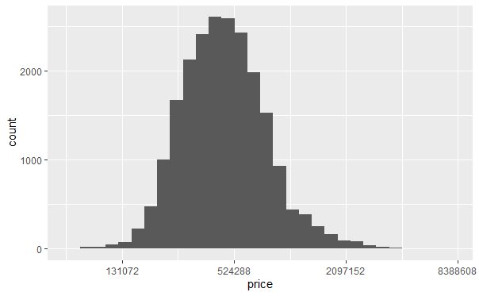

## 2) Check for aliased variables using the alias() function (this takes in a formula object and a data set).

```r
alias(price ~ ., house_tidy)
```

[output not shown]

## 3) Systematically build a regression model containing up to four main effects (remember, a main effect is just a single predictor with coefficient), testing the regression diagnostics as you go

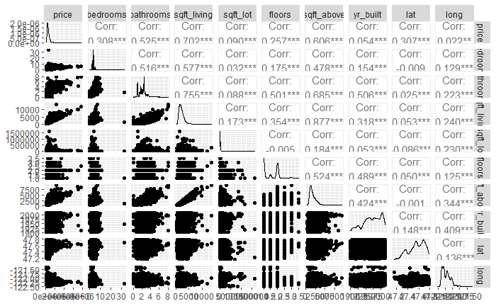

[figure not shown]

### Notes on numerics

- We should consider logs for price, sqft_living and sqft_above b/c they are highly positively skewed.
- sqft_living and sqft_above are the strongest correlations, we should try them first.

```r
house_numeric <- house_numeric %>%
  mutate(
    ln_price = log(price),
    ln_sqft_living = log(sqft_living),
    ln_sqft_above = log(sqft_above)
  )
```

```
Error in mutate(., ln_price = log(price), ln_sqft_living = log(sqft_living),  :
  object 'house_numeric' not found
```

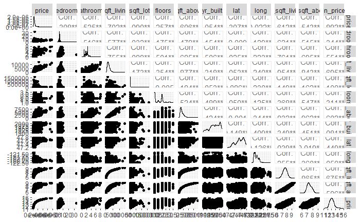

### Notes on log() numerics

The correlation is less strong when using the log() variables, so perhaps we should use the originals and see how the model does

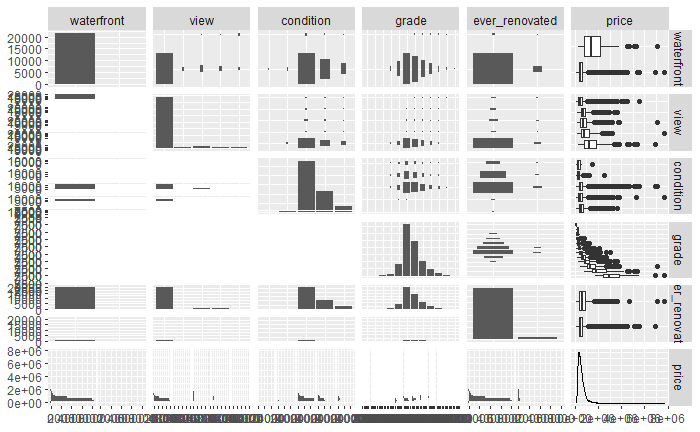

| grade | n |
| --- | --- |
| 1 | 1 |
| 3 | 3 |
| 4 | 29 |
| 5 | 242 |
| 6 | 2038 |
| 7 | 8981 |
| 8 | 6068 |
| 9 | 2615 |
| 10 | 1134 |
| 11 | 399 |

[output cut: 2 more lines]

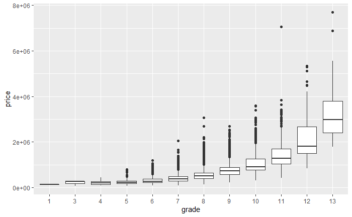

### Notes on nonnumeric

- There looks like there might be a difference by grade, particularly as we get to the builds that are graded as high quality (11-13)
- Waterfront also looks like there might be a difference in price based on whether or not the house is on the waterfront

### First predictor

```r
summary(mod1a)
```

```
Call:
lm(formula = ln_price ~ ln_sqft_living, data = house_tidy)

Residuals:
     Min       1Q   Median       3Q      Max
-1.10511 -0.29300  0.01262  0.25701  1.33011

Coefficients:
               Estimate Std. Error t value Pr(>|t|)
(Intercept)    6.729916   0.047062   143.0   <2e-16 ***
ln_sqft_living 0.836771   0.006223   134.5   <2e-16 ***
---
Signif. codes:  0 ‘***’ 0.001 ‘**’ 0.01 ‘*’ 0.05 ‘.’ 0.1 ‘ ’ 1

Residual standard error: 0.3886 on 21611 degrees of freedom
Multiple R-squared:  0.4555,    Adjusted R-squared:  0.4555
F-statistic: 1.808e+04 on 1 and 21611 DF,  p-value: < 2.2e-16
```

#### Notes

- I tried using non-log values, but the QQ plot was highly skewed, and the residuals vs fitted showed that the model became much more wrong as living sqft increases, so I tried log() values and the diagnostics were much better. I’ve chosen to use them in the model instead because even though the correlations are higher with non-log values, it isn’t by much and the diagnostics indicate we can’t trust them as much.

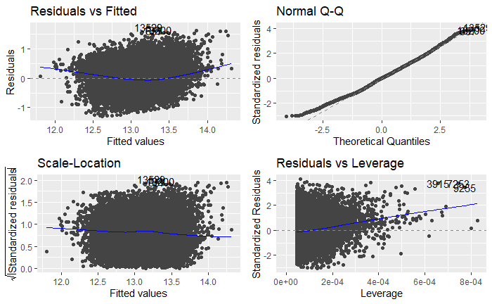

```r
mod1b <- lm(ln_price ~ ln_sqft_above, house_tidy)

autoplot(mod1b)
```

[output not shown]

```r
summary(mod1b)
```

```
Call:
lm(formula = ln_price ~ ln_sqft_above, data = house_tidy)

Residuals:
     Min       1Q   Median       3Q      Max
-1.29338 -0.31877  0.00568  0.28570  1.74047

Coefficients:
              Estimate Std. Error t value Pr(>|t|)
(Intercept)   7.707898   0.050273   153.3   <2e-16 ***
ln_sqft_above 0.722110   0.006787   106.4   <2e-16 ***
---
Signif. codes:  0 ‘***’ 0.001 ‘**’ 0.01 ‘*’ 0.05 ‘.’ 0.1 ‘ ’ 1

Residual standard error: 0.4267 on 21611 degrees of freedom
Multiple R-squared:  0.3438,    Adjusted R-squared:  0.3437
F-statistic: 1.132e+04 on 1 and 21611 DF,  p-value: < 2.2e-16
```

### Check variables against “residue

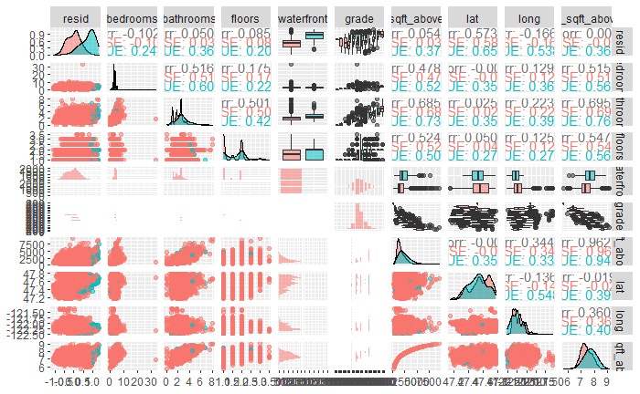

#### Notes on residue

- Waterfront and latitude look interesting.
- King County includes Seattle, so makes sense that as latitude goes up, house price increases since those houses would be closer to Seattle. There could be an interesting interaction between lat and long?

### Second predictor

```r
summary(mod2a)
```

```
Call:
lm(formula = ln_price ~ ln_sqft_living + lat, data = house_tidy)

Residuals:
     Min       1Q   Median       3Q      Max
-1.24482 -0.20493 -0.02026  0.18499  1.33457

Coefficients:
                 Estimate Std. Error t value Pr(>|t|)
(Intercept)    -69.628822   0.743652  -93.63   <2e-16 ***
ln_sqft_living   0.816108   0.005104  159.90   <2e-16 ***
lat              1.608803   0.015647  102.82   <2e-16 ***
---
Signif. codes:  0 ‘***’ 0.001 ‘**’ 0.01 ‘*’ 0.05 ‘.’ 0.1 ‘ ’ 1

Residual standard error: 0.3185 on 21610 degrees of freedom
Multiple R-squared:  0.6344,    Adjusted R-squared:  0.6343
F-statistic: 1.875e+04 on 2 and 21610 DF,  p-value: < 2.2e-16
```

```r
mod2b <- lm(ln_price ~ ln_sqft_living + waterfront,
            data = house_tidy)

summary(mod2b)
```

```
Call:
lm(formula = ln_price ~ ln_sqft_living + waterfront, data = house_tidy)

Residuals:
     Min       1Q   Median       3Q      Max
-1.35282 -0.29040  0.01599  0.25814  1.34260

Coefficients:
               Estimate Std. Error t value Pr(>|t|)
(Intercept)    6.814767   0.046550  146.40   <2e-16 ***
ln_sqft_living 0.824792   0.006158  133.94   <2e-16 ***
waterfrontTRUE 0.741642   0.030236   24.53   <2e-16 ***
---
Signif. codes:  0 ‘***’ 0.001 ‘**’ 0.01 ‘*’ 0.05 ‘.’ 0.1 ‘ ’ 1

Residual standard error: 0.3834 on 21610 degrees of freedom
Multiple R-squared:  0.4703,    Adjusted R-squared:  0.4702
F-statistic:  9592 on 2 and 21610 DF,  p-value: < 2.2e-16
```

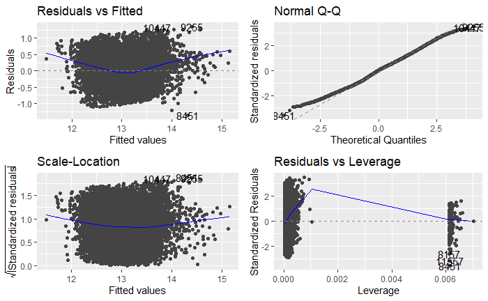

```r
autoplot(mod2b)
```

### Check residue

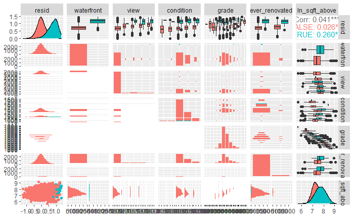

#### Notes on residue

- Grade and waterfront look interesting
- None of the numeric ones seem to be adding much.

### Third predictor

```r
#first trying adding in waterfront
mod3a <- lm(ln_price ~ ln_sqft_living + lat + waterfront,
            data = house_tidy)

summary(mod3a)
```

```
Call:
lm(formula = ln_price ~ ln_sqft_living + lat + waterfront, data = house_tidy)

Residuals:
     Min       1Q   Median       3Q      Max
-1.24306 -0.19986 -0.01568  0.18502  1.26446

Coefficients:
                 Estimate Std. Error t value Pr(>|t|)
(Intercept)    -69.945148   0.726656  -96.26   <2e-16 ***
ln_sqft_living   0.803287   0.005003  160.57   <2e-16 ***
lat              1.617365   0.015290  105.78   <2e-16 ***
waterfrontTRUE   0.786990   0.024547   32.06   <2e-16 ***
---
Signif. codes:  0 ‘***’ 0.001 ‘**’ 0.01 ‘*’ 0.05 ‘.’ 0.1 ‘ ’ 1

Residual standard error: 0.3112 on 21609 degrees of freedom
Multiple R-squared:  0.651, Adjusted R-squared:  0.6509
F-statistic: 1.343e+04 on 3 and 21609 DF,  p-value: < 2.2e-16
```

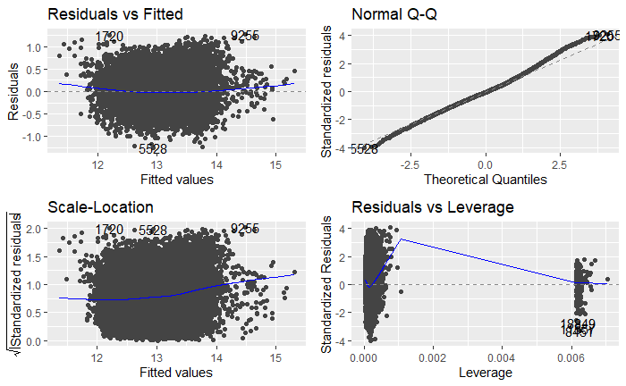

```r
autoplot(mod3a)
```

Improved, but let’s see if grade will be better

```r
anova(mod2a, mod3a)
```

[output not shown]